# Core microbiome

Leo Lahti, Sudarshan Shetty et al.

See also related functions for the analysis of rare and variable taxa (rare_members; rare_abundance; rare_members; rare_abundance; low_abundance).

```r
library("devtools")
#install_github("microbiome/microbiome")
```

# HITChip Data

Load example data:

```r
# Load data
library(microbiome)
data(peerj32)

# Rename the data
pseq <- peerj32$phyloseq

# Calculate compositional version of the data
# (relative abundances)
pseq.rel <- microbiome::transform(pseq, "compositional")
```

## Prevalence of taxonomic groups

Relative population frequencies; at 1% compositional abundance threshold:

```r
head(prevalence(pseq.rel, detection = 1/100, sort = TRUE))
```

```
## Roseburia intestinalis et rel.     Eubacterium hallii et rel.     Clostridium nexile et rel.     Ruminococcus obeum et rel.
##                      1.0000000                      1.0000000                      1.0000000                      0.9772727
##   Coprococcus eutactus et rel.  Ruminococcus lactaris et rel.
##                      0.9772727                      0.9545455
```

Absolute population frequencies (sample count):

```r
head(prevalence(pseq.rel, detection = 1/100, sort = TRUE, count = TRUE))
```

```
## Roseburia intestinalis et rel.     Eubacterium hallii et rel.     Clostridium nexile et rel.     Ruminococcus obeum et rel.
##                             44                             44                             44                             43
##   Coprococcus eutactus et rel.  Ruminococcus lactaris et rel.
##                             43                             42
```

## Core microbiota analysis

If you only need the names of the core taxa, do as follows. This returns the taxa that exceed the given prevalence and detection thresholds.

```r
core.taxa.standard <- core_members(pseq.rel, detection = 0, prevalence = 50/100)
```

A full phyloseq object of the core microbiota is obtained as follows:

```r
pseq.core <- core(pseq.rel, detection = 0, prevalence = .5)
```

We can also collapse the rare taxa into an “Other” category

```r
pseq.core2 <- aggregate_rare(pseq.rel, "Genus", detection = 0, prevalence = .5)
```

Retrieving the core taxa names from the phyloseq object:

```r
core.taxa <- taxa(pseq.core)
```

## Core abundance and diversity

Total core abundance in each sample (sum of abundances of the core members):

```r
core.abundance <- sample_sums(core(pseq.rel, detection = .01, prevalence = .95))
```

## Core line plots

Determine core microbiota across various abundance/prevalence thresholds with the blanket analysis [(Salonen et al. CMI, 2012)](http://onlinelibrary.wiley.com/doi/10.1111/j.1469-0691.2012.03855.x/abstract) based on various signal and prevalences.

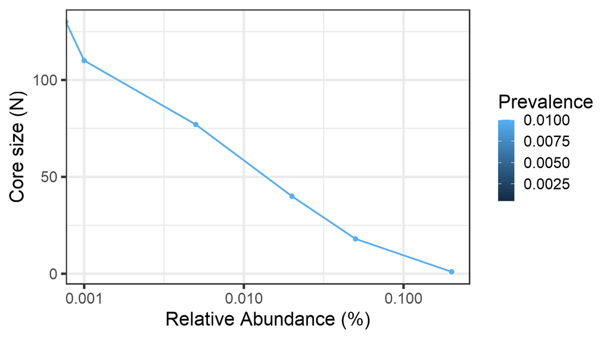

```r
# With compositional (relative) abundances
det <- c(0, 0.1, 0.5, 2, 5, 20)/100
prevalences <- seq(.05, 1, .05)
 #ggplot(d) + geom_point(aes(x, y)) + scale_x_continuous(trans="log10", limits=c(NA,1))


plot_core(pseq.rel,
          prevalences = prevalences,
          detections = det,
          plot.type = "lineplot") +
  xlab("Relative Abundance (%)")
```

## Core heatmaps

This visualization method has been used for instance in [Intestinal microbiome landscaping: Insight in community assemblage and implications for microbial modulation strategies](https://academic.oup.com/femsre/article/doi/10.1093/femsre/fuw045/2979411/Intestinal-microbiome-landscaping-insight-in#58802539). Shetty et al. *FEMS Microbiology Reviews* fuw045, 2017.

Note that you can order the taxa on the heatmap with the taxa.order argument.

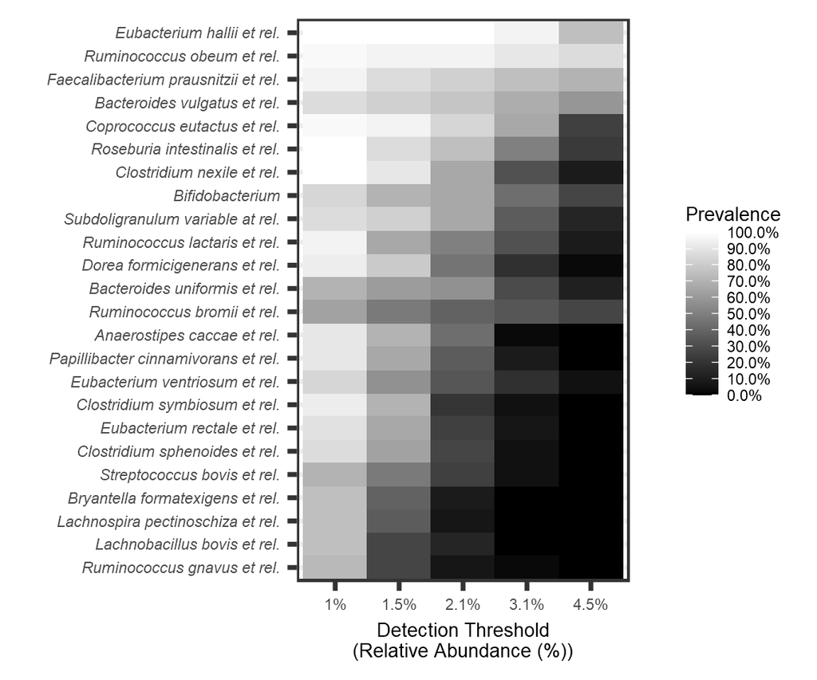

```r
# Core with compositionals:
library(RColorBrewer)
library(reshape)

prevalences <- seq(.05, 1, .05)

detections <- round(10^seq(log10(0.01), log10(.2), length = 9), 3)

# Also define gray color palette
gray <- gray(seq(0,1,length=5))

#Added pseq.rel, I thin... must be checked if it was in the the rednred version,; where it is initialized
#pseq.rel<- microbiome::transform(pseq, 'compositional')
#min-prevalence gets the 100th highest prevalence
p <- plot_core(pseq.rel,
               plot.type = "heatmap",
               colours = gray,
               prevalences = prevalences,
               detections = detections,
               min.prevalence = prevalence(pseq.rel, sort = TRUE)[100]) +
  labs(x = "Detection Threshold\n(Relative Abundance (%))") +

  #Adjusts axis text size and legend bar height
  theme(axis.text.y= element_text(size=8, face="italic"),
        axis.text.x.bottom=element_text(size=8),
        axis.title = element_text(size=10),
        legend.text = element_text(size=8),
        legend.title = element_text(size=10))

print(p)
```

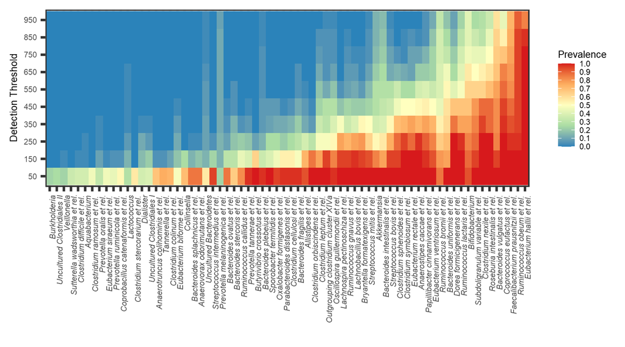

```r
# Core with absolute counts and horizontal view:
# and minimum population prevalence (given as percentage)
detections <- seq(from = 50, to = round(max(abundances(pseq))/10, -1), by = 100)

p <- plot_core(pseq, plot.type = "heatmap",
               prevalences = prevalences,
               detections = detections,
               colours = rev(brewer.pal(5, "Spectral")),
               min.prevalence = .2, horizontal = TRUE) +
  theme(axis.text.x= element_text(size=8, face="italic", hjust=1),
        axis.text.y= element_text(size=8),
        axis.title = element_text(size=10),
        legend.text = element_text(size=8),
        legend.title = element_text(size=10))

print(p)
```

# Core Microbiota using Amplicon data

## Make phyloseq object

This tutorial is useful for analysis of output files from [(Mothur)](https://www.mothur.org/), [(QIIME or QIIME2)](https://qiime2.org/) or any tool that gives a biom file as output. There is also a simple way to read comma seperated (*.csv) files.

Simple comma seperated files:

```r
library(microbiome)


otu.file <-
    system.file("extdata/qiita1629_otu_table.csv",
        package='microbiome')

tax.file <- system.file("extdata/qiita1629_taxonomy_table.csv",
        package='microbiome')

meta.file <- system.file("extdata/qiita1629_mapping_subset.csv",
        package='microbiome')

pseq.csv <- read_phyloseq(
          otu.file=otu.file,
          taxonomy.file=tax.file,
          metadata.file=meta.file, type = "simple")
```

Biom file:

```r
# Read the biom file
biom.file <-
  system.file("extdata/qiita1629.biom",
              package = "microbiome")

# Read the mapping/metadata file
 meta.file <-
  system.file("extdata/qiita1629_mapping.csv",
              package = "microbiome")
# Make phyloseq object
pseq.biom <- read_phyloseq(otu.file = biom.file,
                         metadata.file = meta.file,
                         taxonomy.file = NULL, type = "biom")
```

Mothur shared OTUs and Consensus Taxonomy:

```r
otu.file <- system.file(
 "extdata/Baxter_FITs_Microbiome_2016_fit.final.tx.1.subsample.shared",
    package='microbiome')

tax.file <- system.file(
 "extdata/Baxter_FITs_Microbiome_2016_fit.final.tx.1.cons.taxonomy",
    package='microbiome')

meta.file <- system.file(
 "extdata/Baxter_FITs_Microbiome_2016_mapping.csv",
    package='microbiome')

pseq.mothur <- read_phyloseq(otu.file=otu.file,
        taxonomy.file =tax.file,
        metadata.file=meta.file, type = "mothur")
print(pseq.mothur)
```

[output not shown]

Now, we proceed to core microbiota analysis.

## Core microbiota analysis

Here the data from [Caporaso, J. Gregory, et al. “Moving pictures of the human microbiome.” Genome biology 12.5 (2011): R50.](https://genomebiology.biomedcentral.com/articles/10.1186/gb-2011-12-5-r50?report=reader) will be used which is stored as example in jeevanuDB

```r
# install
# install.packages("devtools")
# devtools::install_github("microsud/jeevanuDB")

# check the data
library(jeevanuDB)
ps <- moving_pictures
table(meta(ps)$sample_type, meta(ps)$host_subject_id)
```

```
##
##           F4  M3
##   saliva 135 373
##   skin   268 723
##   stool  131 336
```

```r
# Filter the data to include only gut samples from M3 subject
ps.m3 <- subset_samples(ps, sample_type == "stool" & host_subject_id == "M3")
print(ps.m3)
```

```
## phyloseq-class experiment-level object
## otu_table()   OTU Table:         [ 3644 taxa and 336 samples ]
## sample_data() Sample Data:       [ 336 samples by 89 sample variables ]
## tax_table()   Taxonomy Table:    [ 3644 taxa by 7 taxonomic ranks ]
```

```r
# keep only taxa with positive sums
ps.m3 <- prune_taxa(taxa_sums(ps.m3) > 0, ps.m3)
print(ps.m3)
```

```
## phyloseq-class experiment-level object
## otu_table()   OTU Table:         [ 611 taxa and 336 samples ]
## sample_data() Sample Data:       [ 336 samples by 89 sample variables ]
## tax_table()   Taxonomy Table:    [ 611 taxa by 7 taxonomic ranks ]
```

```r
# Calculate compositional version of the data
# (relative abundances)
ps.m3.rel <- microbiome::transform(ps.m3, "compositional")
```

Output of deblur/dada2 will most likely have seqs as rownames instead of OTU ids or taxa names

```r
taxa_names(ps.m3.rel)[1:2]
```

```
## [1] "TACGGAGGATTCAAGCGTTATCCGGATTTATTGGGTTTAAAGGGTGCGTAGGCGGTTTGATAAGTTAGAGGTGAAATACCGGTGCTTAACACCGGAACTGCCTCTAATACTGTTGAACTAGAGAGTAGTTGCGGTAGGCGGAATGTATGG"
## [2] "TACGTAGGGTGCGAGCGTTAATCGGAATTACTGGGCGTAAAGCGTGCGCAGGCGGTTTTGTAAGTCAGATGTGAAATCCCCGAGCTCAACTTGGGAACTGCGTTTGAAACTACAAGACTAGAATATGTCAGAGGGGGGTAGAATTCCACG"
```

We can change it to ASVIDs

```r
ps.m3.rel <- microbiome::add_refseq(ps.m3.rel)
# Check if ref_seq slot is added to phyloseq object
print(ps.m3.rel)
```

```
## phyloseq-class experiment-level object
## otu_table()   OTU Table:         [ 611 taxa and 336 samples ]
## sample_data() Sample Data:       [ 336 samples by 89 sample variables ]
## tax_table()   Taxonomy Table:    [ 611 taxa by 7 taxonomic ranks ]
## refseq()      DNAStringSet:      [ 611 reference sequences ]
```

```r
# now check taxa names are ASVids
taxa_names(ps.m3.rel)[1:3]
```

```
## [1] "ASV1" "ASV2" "ASV3"
```

### Core microbiota analysis

If you only need the names of the core taxa, do as follows. This returns the taxa that exceed the given prevalence and detection thresholds.

```r
core.taxa.standard <- core_members(ps.m3.rel, detection = 0.0001, prevalence = 50/100)

core.taxa.standard
```

```
##  [1] "ASV20"  "ASV34"  "ASV35"  "ASV55"  "ASV66"  "ASV88"  "ASV107" "ASV119" "ASV141" "ASV148" "ASV167" "ASV174" "ASV197" "ASV225"
## [15] "ASV226" "ASV233" "ASV260" "ASV279" "ASV293" "ASV303" "ASV317" "ASV326" "ASV329" "ASV330" "ASV341" "ASV352" "ASV358" "ASV361"
## [29] "ASV380" "ASV387" "ASV395" "ASV399" "ASV400" "ASV402" "ASV428" "ASV439" "ASV476" "ASV486" "ASV494" "ASV568" "ASV579" "ASV580"
## [43] "ASV588" "ASV605"
```

We notice that ASV ids by themselves are not informative in this case. In this phyloseq object, the unclassified taxonomic values have a pattern like `k__``to represent kingdom level and so on. We need to change these to NAs. This can be variable depending on your data.

```r
# first combine genus and species names.
tax_table(ps.m3.rel)[tax_table(ps.m3.rel) == "k__"] <- NA
tax_table(ps.m3.rel)[tax_table(ps.m3.rel) == "p__"] <- NA
tax_table(ps.m3.rel)[tax_table(ps.m3.rel) == "c__"] <- NA
tax_table(ps.m3.rel)[tax_table(ps.m3.rel) == "o__"] <- NA
tax_table(ps.m3.rel)[tax_table(ps.m3.rel) == "f__"] <- NA
tax_table(ps.m3.rel)[tax_table(ps.m3.rel) == "g__"] <- NA
tax_table(ps.m3.rel)[tax_table(ps.m3.rel) == "s__"] <- NA

tax_table(ps.m3.rel)[, colnames(tax_table(ps.m3.rel))] <- gsub(tax_table(ps.m3.rel)[, colnames(tax_table(ps.m3.rel))],  pattern = "[a-z]__", replacement = "")

# Use the microbiome function add_besthit to get taxonomic identities of ASVs.
ps.m3.rel.f <- microbiome::add_besthit(ps.m3.rel)

# Check
taxa_names(ps.m3.rel.f)[1:10]
```

```
##  [1] "ASV1:Rikenellaceae"         "ASV2:Methylotenera.mobilis" "ASV3:Blautia"               "ASV4:Peptoniphilus"
##  [5] "ASV5:Lachnospiraceae"       "ASV6:Clostridium"           "ASV7:Lachnospiraceae"       "ASV8:Clostridiales"
##  [9] "ASV9:Lachnospiraceae"       "ASV10:Streptococcus"
```

Now we add the best taxonomic classification available.

```r
core.taxa.standard <- core_members(ps.m3.rel.f, detection = 0.0001, prevalence = 50/100)

core.taxa.standard
```

```
##  [1] "ASV20:Faecalibacterium.prausnitzii"  "ASV34:Oscillospira"                  "ASV35:Odoribacter"
##  [4] "ASV55:Lachnospiraceae"               "ASV66:Lachnospiraceae"               "ASV88:Rikenellaceae"
##  [7] "ASV107:Roseburia"                    "ASV119:Faecalibacterium.prausnitzii" "ASV141:Oscillospira"
## [10] "ASV148:Faecalibacterium"             "ASV167:Faecalibacterium"             "ASV174:Lachnospiraceae"
## [13] "ASV197:Phascolarctobacterium"        "ASV225:Oscillospira"                 "ASV226:Oscillospira"
## [16] "ASV233:[Ruminococcus].torques"       "ASV260:Oscillospira"                 "ASV279:Blautia"
## [19] "ASV293:Holdemania"                   "ASV303:Bacteroides"                  "ASV317:Rikenellaceae"
## [22] "ASV326:Oscillospira"                 "ASV329:Ruminococcus"                 "ASV330:Faecalibacterium.prausnitzii"
## [25] "ASV341:Oscillospira"                 "ASV352:Erysipelotrichaceae"          "ASV358:Lachnospira"
## [28] "ASV361:Oscillospira"                 "ASV380:Bacteroides.ovatus"           "ASV387:Clostridiales"
## [31] "ASV395:Ruminococcaceae"              "ASV399:Oscillospira"                 "ASV400:Parabacteroides"
## [34] "ASV402:Clostridium.colinum"          "ASV428:Blautia.obeum"                "ASV439:Coprococcus"
## [37] "ASV476:Parabacteroides"              "ASV486:Ruminococcus"                 "ASV494:Roseburia"
## [40] "ASV568:Bacteroides.caccae"           "ASV579:Oscillospira"                 "ASV580:Sutterella"
## [43] "ASV588:Lachnospiraceae"              "ASV605:Coprococcus"
```

A full phyloseq object of the core microbiota is obtained as follows:

```r
pseq.core <- core(ps.m3.rel.f, detection = 0.0001, prevalence = .5)
```

Retrieving the associated taxonomy from the phyloseq object:

```r
core.taxa <- taxa(pseq.core)
class(core.taxa)
```

```
## [1] "character"
```

```r
# get the taxonomy data
tax.mat <- tax_table(pseq.core)
tax.df <- as.data.frame(tax.mat)

# add the OTus to last column
tax.df$OTU <- rownames(tax.df)

# select taxonomy of only
# those OTUs that are core memebers based on the thresholds that were used.
core.taxa.class <- dplyr::filter(tax.df, rownames(tax.df) %in% core.taxa)
knitr::kable(head(core.taxa.class))
```

|  | Domain | Phylum | Class | Order | Family | Genus | Species | OTU |
| --- | --- | --- | --- | --- | --- | --- | --- | --- |
| ASV20:Faecalibacterium.prausnitzii | Bacteria | Firmicutes | Clostridia | Clostridiales | Ruminococcaceae | Faecalibacterium | prausnitzii | ASV20:Faecalibacterium.prausnitzii |
| ASV34:Oscillospira | Bacteria | Firmicutes | Clostridia | Clostridiales | Ruminococcaceae | Oscillospira | NA | ASV34:Oscillospira |
| ASV35:Odoribacter | Bacteria | Bacteroidetes | Bacteroidia | Bacteroidales | [Odoribacteraceae] | Odoribacter | NA | ASV35:Odoribacter |
| ASV55:Lachnospiraceae | Bacteria | Firmicutes | Clostridia | Clostridiales | Lachnospiraceae | NA | NA | ASV55:Lachnospiraceae |
| ASV66:Lachnospiraceae | Bacteria | Firmicutes | Clostridia | Clostridiales | Lachnospiraceae | NA | NA | ASV66:Lachnospiraceae |
| ASV88:Rikenellaceae | Bacteria | Bacteroidetes | Bacteroidia | Bacteroidales | Rikenellaceae | NA | NA | ASV88:Rikenellaceae |

## Core visualization

### Core line plots

Determine core microbiota across various abundance/prevalence thresholds with the blanket analysis [(Salonen et al. CMI, 2012)](http://onlinelibrary.wiley.com/doi/10.1111/j.1469-0691.2012.03855.x/abstract) based on various signal and prevalences.

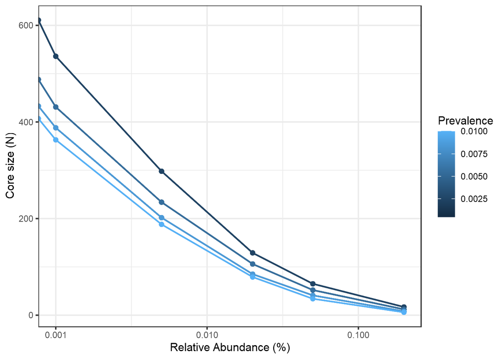

```r
# With compositional (relative) abundances
det <- c(0, 0.1, 0.5, 2, 5, 20)/100
prevalences <- seq(.05, 1, .05)

plot_core(ps.m3.rel.f, prevalences = prevalences,
          detections = det, plot.type = "lineplot") +
  xlab("Relative Abundance (%)") +
  theme_bw()
```

### Core heatmaps

This visualization method has been used for instance in [Intestinal microbiome landscaping: Insight in community assemblage and implications for microbial modulation strategies](https://academic.oup.com/femsre/article/doi/10.1093/femsre/fuw045/2979411/Intestinal-microbiome-landscaping-insight-in#58802539). Shetty et al. *FEMS Microbiology Reviews* fuw045, 2017.

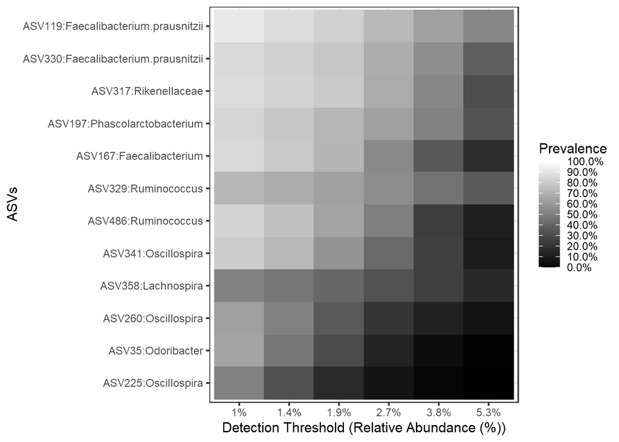

```r
# Core with compositionals:
prevalences <- seq(.05, 1, .05)
detections <- round(10^seq(log10(1e-2), log10(.2), length = 10), 3)

#Deletes "ASV" from taxa_names, e.g. ASV1 --> 1
#taxa_names(ps.m3.rel) = taxa_names(ps.m3.rel) %>% str_replace("ASV", "")
# Also define gray color palette
gray <- gray(seq(0,1,length=5))

p1 <- plot_core(ps.m3.rel.f,
  plot.type = "heatmap",
  colours = gray,
  prevalences = prevalences,
  detections = detections, min.prevalence = .5) +
  xlab("Detection Threshold (Relative Abundance (%))")

p1 <- p1 + theme_bw() + ylab("ASVs")
p1
```

Using viridis color palette

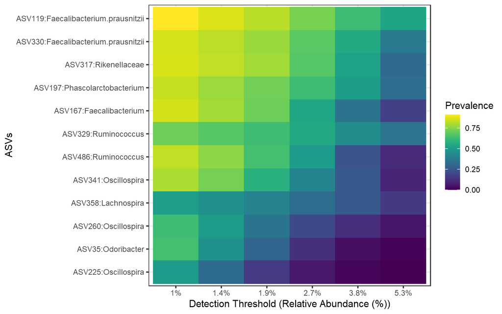

```r
library(viridis)
print(p1 + scale_fill_viridis())
```

## Genus level

```r
ps.m3.rel.gen <- aggregate_taxa(ps.m3.rel, "Genus")

# Check if any taxa with no genus classification. aggregate_taxa will merge all unclassified to Unknown
any(taxa_names(ps.m3.rel.gen) == "Unknown")
```

```
## [1] TRUE
```

```r
# Remove Unknown
ps.m3.rel.gen <- subset_taxa(ps.m3.rel.gen, Genus!="Unknown")
```

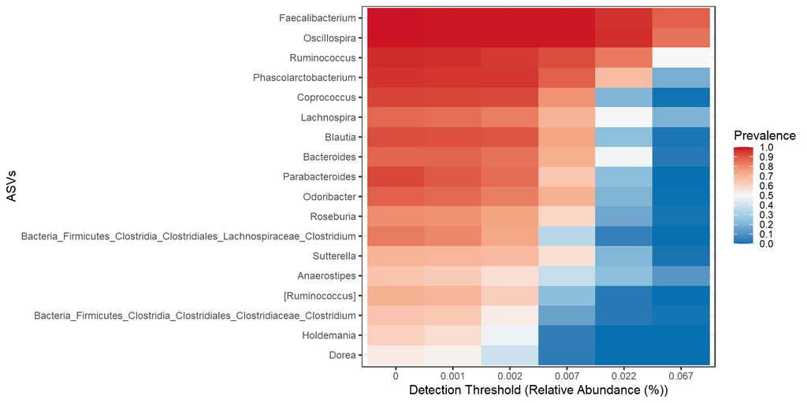

```r
library(RColorBrewer)
prevalences <- seq(.05, 1, .05)
detections <- round(10^seq(log10(1e-5), log10(.2), length = 10), 3)

p1 <- plot_core(ps.m3.rel.gen,
                plot.type = "heatmap",
                colours = rev(brewer.pal(5, "RdBu")),
                prevalences = prevalences,
                detections = detections, min.prevalence = .5) +
    xlab("Detection Threshold (Relative Abundance (%))")
p1 <- p1 + theme_bw() + ylab("ASVs")
p1
```

Some taxa name are long. Shorten them as follows and plot.

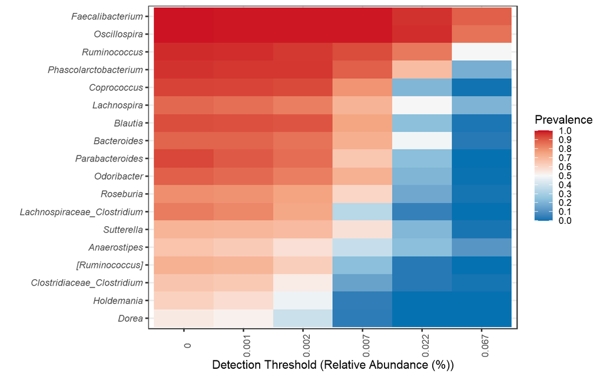

```r
taxa_names(ps.m3.rel.gen) <- gsub("Bacteria_Firmicutes_Clostridia_Clostridiales_",
                                  "", taxa_names(ps.m3.rel.gen))
p1 <- plot_core(ps.m3.rel.gen,
                plot.type = "heatmap",
                colours = rev(brewer.pal(5, "RdBu")),
                prevalences = prevalences,
                detections = detections, min.prevalence = .5) +
    xlab("Detection Threshold (Relative Abundance (%))") +
  theme_bw() +
  theme(axis.text.x = element_text(angle=90),
        axis.text.y = element_text(face = "italic"))

p1
```